[figure not shown]

# Проект: Анализ резюме из HeadHunter

```python
import pandas as pd
import numpy as np
import matplotlib.pyplot as plt
import seaborn as sns
import plotly.express as px
```

# Исследование структуры данных

1. Прочитайте данные с помощью библиотеки Pandas. Совет: перед чтением обратите внимание на разделитель внутри файла.

```python
hh_df = pd.read_csv('dst-3.0_16_1_hh_database.csv', sep=';')
```

2. Выведите несколько первых (последних) строк таблицы, чтобы убедиться в том, что ваши данные не повреждены. Ознакомьтесь с признаками и их структурой.

```python
display(hh_df.head(5))
display(hh_df.tail(5))

display(hh_df.shape)
```

|  | Пол, возраст | ЗП | Ищет работу на должность: | Город, переезд, командировки | Занятость | График | Опыт работы | Последнее/нынешнее место работы | Последняя/нынешняя должность | Образование и ВУЗ | Обновление резюме | Авто |
| --- | --- | --- | --- | --- | --- | --- | --- | --- | --- | --- | --- | --- |
| 0 | Мужчина , 39 лет , родился 27 ноября 1979 | 29000 руб. | Системный администратор | Советск (Калининградская область) , не готов к... | частичная занятость, проектная работа, полная ... | гибкий график, полный день, сменный график, ва... | Опыт работы 16 лет 10 месяцев Август 2010 — п... | МАОУ "СОШ № 1 г.Немана" | Системный администратор | Неоконченное высшее образование 2000 Балтийск... | 16.04.2019 15:59 | Имеется собственный автомобиль |
| 1 | Мужчина , 60 лет , родился 20 марта 1959 | 40000 руб. | Технический писатель | Королев , не готов к переезду , готов к редким... | частичная занятость, проектная работа, полная ... | гибкий график, полный день, сменный график, уд... | Опыт работы 19 лет 5 месяцев Январь 2000 — по... | Временный трудовой коллектив | Менеджер проекта, Аналитик, Технический писатель | Высшее образование 1981 Военно-космическая ак... | 12.04.2019 08:42 | Не указано |
| 2 | Женщина , 36 лет , родилась 12 августа 1982 | 20000 руб. | Оператор | Тверь , не готова к переезду , не готова к ком... | полная занятость | полный день | Опыт работы 10 лет 3 месяца Октябрь 2004 — Де... | ПАО Сбербанк | Кассир-операционист | Среднее специальное образование 2002 Профессио... | 16.04.2019 08:35 | Не указано |
| 3 | Мужчина , 38 лет , родился 25 июня 1980 | 100000 руб. | Веб-разработчик (HTML / CSS / JS / PHP / базы ... | Саратов , не готов к переезду , готов к редким... | частичная занятость, проектная работа, полная ... | гибкий график, удаленная работа | Опыт работы 18 лет 9 месяцев Август 2017 — Ап... | OpenSoft | Инженер-программист | Высшее образование 2002 Саратовский государст... | 08.04.2019 14:23 | Не указано |
| 4 | Женщина , 26 лет , родилась 3 марта 1993 | 140000 руб. | Региональный менеджер по продажам | Москва , не готова к переезду , готова к коман... | полная занятость | полный день | Опыт работы 5 лет 7 месяцев Региональный мене... | Мармелад | Менеджер по продажам | Высшее образование 2015 Кгу Психологии и педаг... | 22.04.2019 10:32 | Не указано |

|  | Пол, возраст | ЗП | Ищет работу на должность: | Город, переезд, командировки | Занятость | График | Опыт работы | Последнее/нынешнее место работы | Последняя/нынешняя должность | Образование и ВУЗ | Обновление резюме | Авто |
| --- | --- | --- | --- | --- | --- | --- | --- | --- | --- | --- | --- | --- |
| 44739 | Мужчина , 30 лет , родился 17 января 1989 | 50000 руб. | Финансист, аналитик, экономист, бухгалтер, мен... | Тверь , готов к переезду (Москва, Химки) , гот... | полная занятость | полный день, удаленная работа | Опыт работы 7 лет 7 месяцев Финансист, аналит... | ООО "IAS" (независимый участник объединения Ru... | Руководитель субгруппы | Высшее образование 2015 Московский гуманитарн... | 22.04.2019 12:32 | Не указано |
| 44740 | Мужчина , 27 лет , родился 5 марта 1992 | 39000 руб. | Системный администратор, IT-специалист | Липецк , готов к переезду , готов к командировкам | проектная работа, частичная занятость, полная ... | удаленная работа, гибкий график, полный день, ... | Опыт работы 7 лет Системный администратор, IT... | ИП Пестрецов | Предприниматель | Высшее образование (Бакалавр) 2016 Воронежски... | 22.04.2019 13:11 | Не указано |
| 44741 | Женщина , 48 лет , родилась 26 декабря 1970 | 40000 руб. | Аналитик данных, Математик | Челябинск , готова к переезду , готова к редки... | полная занятость | полный день, удаленная работа | Опыт работы 21 год 5 месяцев Январь 1998 — по... | ОАО «ЧМК», Исследовательско-Технологический Це... | Начальник группы аналитики | Высшее образование 2000 Южно-Уральский госуда... | 09.04.2019 05:07 | Не указано |
| 44742 | Мужчина , 24 года , родился 6 октября 1994 | 20000 руб. | Контент-менеджер | Тамбов , не готов к переезду , не готов к кома... | частичная занятость, полная занятость | удаленная работа | Опыт работы 3 года 10 месяцев Контент-менедже... | IQ-Maxima | Менеджер проектов | Высшее образование 2015 Тамбовский государств... | 26.04.2019 14:25 | Имеется собственный автомобиль |
| 44743 | Мужчина , 38 лет , родился 25 апреля 1980 | 120000 руб. | Руководитель проекта | Москва , не готов к переезду , не готов к кома... | полная занятость | полный день | Опыт работы 15 лет 10 месяцев Руководитель пр... | ПАО ГК ТНС энерго | Руководитель отдела технической поддержки | Высшее образование 1997 Южно-Российский госуд... | 05.07.2018 20:15 | Не указано |

```
(44744, 12)
```

3. Выведите основную информацию о числе непустых значений в столбцах и их типах в таблице.
4. Обратите внимание на информацию о числе непустых значений.

```python
hh_df.info()
```

```
<class 'pandas.core.frame.DataFrame'>
RangeIndex: 44744 entries, 0 to 44743
Data columns (total 12 columns):
 #   Column                           Non-Null Count  Dtype
---  ------                           --------------  -----
 0   Пол, возраст                     44744 non-null  object
 1   ЗП                               44744 non-null  object
 2   Ищет работу на должность:        44744 non-null  object
 3   Город, переезд, командировки     44744 non-null  object
 4   Занятость                        44744 non-null  object
 5   График                           44744 non-null  object
 6   Опыт работы                      44576 non-null  object
 7   Последнее/нынешнее место работы  44743 non-null  object
 8   Последняя/нынешняя должность     44742 non-null  object
 9   Образование и ВУЗ                44744 non-null  object
 10  Обновление резюме                44744 non-null  object
 11  Авто                             44744 non-null  object
dtypes: object(12)
memory usage: 4.1+ MB
```

5. Выведите основную статистическую информацию о столбцах.

```python
hh_df.describe()
```

|  | Пол, возраст | ЗП | Ищет работу на должность: | Город, переезд, командировки | Занятость | График | Опыт работы | Последнее/нынешнее место работы | Последняя/нынешняя должность | Образование и ВУЗ | Обновление резюме | Авто |
| --- | --- | --- | --- | --- | --- | --- | --- | --- | --- | --- | --- | --- |
| count | 44744 | 44744 | 44744 | 44744 | 44744 | 44744 | 44576 | 44743 | 44742 | 44744 | 44744 | 44744 |
| unique | 16003 | 690 | 14929 | 10063 | 38 | 47 | 44413 | 30214 | 16927 | 40148 | 18838 | 2 |
| top | Мужчина , 32 года , родился 17 сентября 1986 | 50000 руб. | Системный администратор | Москва , не готов к переезду , не готов к кома... | полная занятость | полный день | Опыт работы 10 лет 8 месяцев Апрель 2018 — по... | Индивидуальное предпринимательство / частная п... | Системный администратор | Высшее образование 1987 Военный инженерный Кра... | 07.05.2019 09:50 | Не указано |
| freq | 18 | 4064 | 3099 | 1261 | 30026 | 22727 | 3 | 935 | 2062 | 4 | 25 | 32268 |

```python
# Сколько уникальных значений содержится в столбце «Опыт работы»?
hh_df.nunique()
hh_df['Ищет работу на должность:'].value_counts().sort_values()
```

```
Ищет работу на должность:
Project Manager - Менеджер проектов        1
Разработчик 1С-Битрикс Backend             1
Специалист в ИТ                            1
Yachtbroker (брокер по продажам яхт)       1
Программист (удаленно)                     1
                                        ...
Руководитель проекта                     718
Менеджер проектов                        745
Аналитик                                 809
Инженер                                  966
Системный администратор                 3099
Name: count, Length: 14929, dtype: int64
```

```python
# Посмотрим, какие уровни образования указаны
hh_df['Образование и ВУЗ'].unique()
```

```
array(['Неоконченное высшее образование 2000  Балтийская государственная академия рыбопромыслового флота, Калининград судоводительский, Организация и безопасность движения',
       'Высшее образование 1981  Военно-космическая академия им. А.Ф. Можайского, Санкт-Петербург АСУ, АСУ',
       'Среднее специальное образование 2002 Профессиональный лицей 39 г. Твери Экономический, Банковское дело',
       ...,
       'Высшее образование (Бакалавр) 2016  Воронежский государственный университет, Воронеж Факультет журналистики , Реклама и связи с общественностью, Связи с общественностью 2012 Воронежский государственный технический университет, Воронеж Естественно-технический колледж , Вычислительные машины, …
       'Высшее образование 2000  Южно-Уральский государственный университет (Национальный исследовательский университет), Челябинск Приборостроительный факультет, ЭВМ 1993 Челябинский государственный университет, Челябинск Математический факультет, Математик',
       'Высшее образование 1997  Южно-Российский государственный технический университет (Новочеркасский политехнический институт), Новочеркасск ТМиР, Организация и управление технической эксплуатацией техники'],
      dtype=object)
```

# Преобразование данных

1. Начнем с простого - с признака **"Образование и ВУЗ"**. Его текущий формат это: **<Уровень образования год выпуска ВУЗ специальность...>**. Например:
- Высшее образование 2016 Московский авиационный институт (национальный исследовательский университет)...
- Неоконченное высшее образование 2000 Балтийская государственная академия рыбопромыслового флота… Нас будет интересовать только уровень образования.

Создайте с помощью функции-преобразования новый признак **"Образование"**, который должен иметь 4 категории: "высшее", "неоконченное высшее", "среднее специальное" и "среднее".

Выполните преобразование, ответьте на контрольные вопросы и удалите признак "Образование и ВУЗ".

Совет: обратите внимание на структуру текста в столбце **"Образование и ВУЗ"**. Гарантируется, что текущий уровень образования соискателя всегда находится в первых 2ух слов и начинается с заглавной буквы. Воспользуйтесь этим.

*Совет: проверяйте полученные категории, например, с помощью метода unique()*

```python
# --> Выделим категории для образования
education = [
    'высшее',
    'неоконченное высшее',
    'среднее',
    'среднее специальное',
]
```

```python
# Функция извлечения уровня образования
# input: arg - строка, содержащая информацию об уровне образования из признака 'Образование и ВУЗ'
# output: строка - уровень образования, преобразованный в одну из 4 категорий (education)
def get_education(arg):
    # Выделим интересующую нас часть из 'Образование и ВУЗ'
    arg = ' '.join(arg.split(' ')[:3])
    if 'Высшее' in arg:
        return 'высшее'
    elif 'Неоконченное высшее' in arg:
        return 'неоконченное высшее'
    elif 'Среднее специальное' in arg:
        return 'среднее специальное'
    elif 'Среднее образование' in arg:
        return 'среднее'

# Cоздаём и удаляем признаки
hh_df['Образование'] = hh_df['Образование и ВУЗ'].apply(get_education)
hh_df.drop('Образование и ВУЗ', axis = 1, inplace = True)
```

```python
# Сколько соискателей имеет средний уровень образования (школьное образование)?
hh_df['Образование'].value_counts().loc['среднее']
```

```
559
```

```python
# Проверка признака
hh_df['Образование'].value_counts()
```

```
Образование
высшее                 33863
среднее специальное     5765
неоконченное высшее     4557
среднее                  559
Name: count, dtype: int64
```

2. Теперь нас интересует столбец **"Пол, возраст"**. Сейчас он представлен в формате **<Пол , возраст , дата рождения >**. Например:
- Мужчина , 39 лет , родился 27 ноября 1979
- Женщина , 21 год , родилась 13 января 2000 Как вы понимаете, нам необходимо выделить каждый параметр в отдельный столбец.

Создайте два новых признака **"Пол"** и **"Возраст"**. При этом важно учесть:

- Признак пола должен иметь 2 уникальных строковых значения: 'М' - мужчина, 'Ж' - женщина.
- Признак возраста должен быть представлен целыми числами.

Выполните преобразование, ответьте на контрольные вопросы и удалите признак **"Пол, возраст"** из таблицы.

*Совет: обратите внимание на структуру текста в столбце, в части на то, как разделены параметры пола, возраста и даты рождения между собой - символом ' , '. Гарантируется, что структура одинакова для всех строк в таблице. Вы можете воспользоваться этим.*

```python
# input: arg - строка, содержащая информацию о поле и возрасте из признака 'Пол, возраст'
# output: строка, содержащая пол, преобразованный в одну из 2 категорий - М и Ж
def get_sex(arg):
    if 'Мужчина' in arg:
        return 'М'
    else:
        return 'Ж'
```

```python
# input: arg - строка, содержащая информацию о поле и возрасте из признака 'Пол, возраст'
# output: строка, содержащая возраст
def get_age(arg):
    # Нас интересуте только возраст, не пол. Поэьлму берем по индексу 1
    age = arg.split(sep=',', maxsplit=1)[1]
    age = int(age.split()[0])

    return age

# Создаём и удаляем признаки
hh_df['Пол'] = hh_df['Пол, возраст'].agg([get_sex])
hh_df['Возраст'] = hh_df['Пол, возраст'].agg([get_age])
hh_df.drop(columns='Пол, возраст', inplace=True)
```

```python
# Проверка признаков
hh_df['Пол'].value_counts()
```

```
Пол
М    36211
Ж     8533
Name: count, dtype: int64
```

```python
# Сколько процентов женских резюме представлено в наших данных? Ответ округлите до сотых.
round((len(hh_df[hh_df['Пол'] == 'Ж']) / len(hh_df['Пол'])) * 100, 2)
```

```
19.07
```

```python
hh_df['Возраст'].value_counts()
```

```
Возраст
30     2834
29     2765
28     2748
31     2675
27     2583
       ...
15        2
77        1
76        1
14        1
100       1
Name: count, Length: 63, dtype: int64
```

```python
# Чему равен средний возраст соискателей? Ответ округлите до десятых.
round(hh_df['Возраст'].mean(), 2)
```

```
32.2
```

3. Следующим этапом преобразуем признак **"Опыт работы"**. Его текущий формат - это: **<Опыт работы: n лет m месяцев, периоды работы в различных компаниях…>**.

Из столбца нам необходимо выделить общий опыт работы соискателя в месяцах, новый признак назовем "Опыт работы (месяц)"

Для начала обсудим условия решения задачи:

- Во-первых, в данном признаке есть пропуски. Условимся, что если мы встречаем пропуск, оставляем его как есть (функция-преобразование возвращает NaN)
- Во-вторых, в данном признаке есть скрытые пропуски. Для некоторых соискателей в столбце стоит значения "Не указано". Их тоже обозначим как NaN (функция-преобразование возвращает NaN)
- В-третьих, нас не интересует информация, которая описывается после указания опыта работы (периоды работы в различных компаниях)
- В-четвертых, у нас есть проблема: опыт работы может быть представлен только в годах или только месяцах. Например, можно встретить следующие варианты:
  - Опыт работы 3 года 2 месяца…
  - Опыт работы 4 года…
  - Опыт работы 11 месяцев…
  - Учитывайте эту особенность в вашем коде

Учитывайте эту особенность в вашем коде

В результате преобразования у вас должен получиться столбец, содержащий информацию о том, сколько месяцев проработал соискатель. Выполните преобразование, ответьте на контрольные вопросы и удалите столбец **"Опыт работы"** из таблицы.

```python
# input: arg - строка, содержащая информацию о поле и возрасте из признака 'Опыт работы'
# output: строка, содержащая суммарный трудовой опыт в месяцах
def get_experience(arg):
    if (pd.isna(arg) or arg == 'Не указано'):
        return None

    years = ['год', 'года', 'лет']
    months = ['месяц', 'месяца', 'месяцев']

    arg_splitted = arg.split(' ')[:7]
    if (arg_splitted[3] in years):
        if (len(arg_splitted) > 4) and (arg_splitted[5] in months):
            return int(arg_splitted[2]) * 12 + int(arg_splitted[4])
        return int(arg_splitted[2]) * 12
    return int(arg_splitted[2])
```

```python
# Создаём и удаляем признаки
hh_df['Опыт работы (месяц)'] = hh_df['Опыт работы'].apply(get_experience)
hh_df.drop(columns='Опыт работы', inplace=True)

# Проверка признака
hh_df['Опыт работы (месяц)'].value_counts()
```

```
Опыт работы (месяц)
81.0     313
68.0     306
80.0     286
92.0     286
64.0     285
        ...
517.0      1
526.0      1
556.0      1
473.0      1
622.0      1
Name: count, Length: 517, dtype: int64
```

```python
# Чему равен медианный опыт работы (в месяцах) в нашей таблице?
hh_df['Опыт работы (месяц)'].median()
```

```
100.0
```

4. Хорошо идем! Следующий на очереди признак "Город, переезд, командировки". Информация в нем представлена в следующем виде: **<Город , (метро) , готовность к переезду (города для переезда) , готовность к командировкам>**. В скобках указаны необязательные параметры строки. Например, можно встретить следующие варианты:
- Москва , не готов к переезду , готов к командировкам
- Москва , м. Беломорская , не готов к переезду, не готов к командировкам
- Воронеж , готов к переезду (Сочи, Москва, Санкт-Петербург) , готов к командировкам

Создадим отдельные признаки **"Город"**, **"Готовность к переезду"**, **"Готовность к командировкам"**. При этом важно учесть:

- Признак **"Город"** должен содержать только 4 категории: "Москва", "Санкт-Петербург" и "город-миллионник" (их список ниже), остальные обозначьте как "другие".

  Список городов-миллионников:

  `million_cities = ['Новосибирск', 'Екатеринбург','Нижний Новгород','Казань', 'Челябинск','Омск', 'Самара', 'Ростов-на-Дону', 'Уфа', 'Красноярск', 'Пермь', 'Воронеж','Волгоград']` Инфорация о метро, рядом с которым проживает соискатель нас не интересует.
- Признак **"Готовность к переезду"** должен иметь два возможных варианта: True или False. Обратите внимание, что возможны несколько вариантов описания готовности к переезду в признаке "Город, переезд, командировки". Например:
  - … , готов к переезду , …
  - … , не готова к переезду , …
  - … , готова к переезду (Москва, Санкт-Петербург, Ростов-на-Дону)
  - … , хочу переехать (США) , …

  Нас интересует только сам факт возможности или желания переезда.
- Признак **"Готовность к командировкам"** должен иметь два возможных варианта: True или False. Обратите внимание, что возможны несколько вариантов описания готовности к командировкам в признаке "Город, переезд, командировки". Например:
  - … , готов к командировкам , …
  - … , готова к редким командировкам , …
  - … , не готов к командировкам , …

  Нас интересует только сам факт готовности к командировке.

  Еще один важный факт: при выгрузки данных у некоторых соискателей "потерялась" информация о готовности к командировкам. Давайте по умолчанию будем считать, что такие соискатели не готовы к командировкам.

Выполните преобразования и удалите столбец **"Город, переезд, командировки"** из таблицы.

*Совет: обратите внимание на то, что структура текста может меняться в зависимости от указания ближайшего метро. Учите это, если будете использовать порядок слов в своей программе.*

```python
# input: arg - строка, содержащая информацию из признака 'Город, переезд, командировки'
# output: строка, содержащая город, преобразованный в одну из 4 категорий - Москва, Санкт-Петербург,
#         город-миллионник или другие (усл. 1)
def get_city(arg):
    million_cities = ['Новосибирск', 'Екатеринбург','Нижний Новгород',
                     'Казань', 'Челябинск','Омск', 'Самара', 'Ростов-на-Дону',
                     'Уфа', 'Красноярск', 'Пермь', 'Воронеж','Волгоград']
    city = arg.split(' , ')[0]
    if city in million_cities:
        return 'город-миллионник'
    elif (city == 'Москва') or (city == 'Санкт-Петербург'):
        return city
    else:
        return 'другие'
```

```python
# input: arg - строка, содержащая информацию из признака 'Город, переезд, командировки'
# output: строка, содержащая признак, преобразованный в одну из 2 категорий - True или False
def get_ready_to_relocation(arg):
    if ('не готов к переезду' in arg) or ('не готова к переезду' in arg):
        return False
    elif 'хочу' in arg:
        return True
    else:
        return True
```

```python
# input: arg - строка, содержащая информацию о готовности к командировкам 'Город, переезд, командировки'
# output: строка, содержащая признак, преобразованный в одну из 2 категорий - True или False
def get_ready_for_business_trips(arg):
    if ('командировка' in arg):
        if ('не готов к командировкам' in arg) or ('не готова к командировкам' in arg):
            return False
        else:
            return True
    else:
        return False # default (в случае отсутствующего значения)
```

```python
# Cоздаём и удаляем признаки
hh_df['Город'] = hh_df['Город, переезд, командировки'].apply(get_city)
hh_df['Готовность к переезду'] = hh_df['Город, переезд, командировки'].apply(get_ready_to_relocation)
hh_df['Готовность к командировкам'] = hh_df['Город, переезд, командировки'].apply(get_ready_for_business_trips)

hh_df.drop(columns='Город, переезд, командировки', inplace=True)
```

```python
# Проверка признаков
hh_df['Город'].value_counts().sort_index()
hh_df['Готовность к переезду'].value_counts().sort_index()
hh_df['Готовность к командировкам'].value_counts().sort_index()
```

```
Готовность к командировкам
False    13104
True     31640
Name: count, dtype: int64
```

```python
# Сколько процентов соискателей живут в Санкт-Петербурге? Ответ округлите до целого.
round(hh_df['Город'].value_counts(normalize=True).loc['Санкт-Петербург'] * 100)
```

```
11
```

```python
# Сколько процентов соискателей готовы одновременно и к переездам, и к командировкам? Ответ округлите до целого.
ready_to_relocate = hh_df['Готовность к переезду']
ready_for_business_trips = hh_df['Готовность к командировкам']
round(hh_df[ready_to_relocate & ready_for_business_trips].shape[0] / hh_df.shape[0]*100)
```

```
32
```

5. Рассмотрим поближе признаки **"Занятость"** и **"График"**. Сейчас признаки представляют собой набор категорий желаемой занятости (полная занятость, частичная занятость, проектная работа, волонтерство, стажировка) и желаемого графика работы (полный день, сменный график, гибкий график, удаленная работа, вахтовый метод). На сайте hh.ru соискатель может указывать различные комбинации данных категорий, например:
- полная занятость, частичная занятость
- частичная занятость, проектная работа, волонтерство
- полный день, удаленная работа
- вахтовый метод, гибкий график, удаленная работа, полная занятость

Такой вариант признаков имеет множество различных комбинаций, а значит множество уникальных значений, что мешает анализу. Нужно это исправить!

Давайте создадим признаки-мигалки для каждой категории: если категория присутствует в списке желаемых соискателем, то в столбце на месте строки рассматриваемого соискателя ставится True, иначе - False.

Такой метод преобразования категориальных признаков называется One Hot Encoding и его схема представлена на рисунке ниже:

[figure not shown]

Выполните данное преобразование для признаков "Занятость" и "График", ответьте на контрольные вопросы, после чего удалите их из таблицы

```python
employment_type = ['полная занятость',
                   'частичная занятость',
                   'проектная работа',
                   'волонтерство',
                   'стажировка']

schedule = ['полный день',
            'сменный график',
            'гибкий график',
            'удаленная работа',
            'вахтовый метод']

for str in employment_type:
    hh_df[str.capitalize()] = hh_df['Занятость'].agg(lambda x:
        True if str in x else False)

for str in schedule:
    hh_df[str.capitalize()] = hh_df['График'].agg(lambda x:
        True if str in x else False)

# Удаляем признаки
hh_df.drop(columns=['Занятость', 'График'], inplace=True)
```

[output not shown]

```python
# Проверка признаков
for str in employment_type:
    hh_df[str.capitalize()].value_counts().sort_index(ascending=False)

for str in schedule:
    hh_df[str.capitalize()].value_counts().sort_index(ascending=False)
```

```python
# Сколько людей ищут проектную работу и волонтёрство (в обоих столбцах стоит True)?
project_work = hh_df['Проектная работа'] == True
volunteer_work = hh_df['Волонтерство'] == True
hh_df[project_work & volunteer_work].shape[0]
```

```
436
```

```python
# Сколько людей хотят работать вахтовым методом и с гибким графиком (в обоих столбцах стоит True)?
rotation_basis = hh_df['Вахтовый метод'] == True
flexible_shifts = hh_df['Гибкий график'] == True
hh_df[rotation_basis & flexible_shifts].shape[0]
```

```
2311
```

6. (2 балла) Наконец, мы добрались до самого главного и самого важного - признака заработной платы **"ЗП"**. В чем наша беда? В том, что помимо желаемой заработной платы соискатель указывает валюту, в которой он бы хотел ее получать, например:
- 30000 руб.
- 50000 грн.
- 550 USD

Нам бы хотелось видеть заработную плату в единой валюте, например, в рублях. Возникает вопрос, а где взять курс валют по отношению к рублю?

На самом деле язык Python имеет в арсенале огромное количество возможностей получения данной информации, от обращения к API Центробанка, до использования специальных библиотек, например pycbrf. Однако, это не тема нашего проекта.

Поэтому мы пойдем в лоб: обратимся к специальным интернет-ресурсам для получения данных о курсе в виде текстовых файлов. Например, MDF.RU, данный ресурс позволяет удобно экспортировать данные о курсах различных валют и акций за указанные периоды в виде csv файлов. Мы уже сделали выгрузку курсов валют, которые встречаются в наших данных за период с 29.12.2017 по 05.12.2019. Скачать ее вы можете **на платформе**

Создайте новый DataFrame из полученного файла. В полученной таблице нас будут интересовать столбцы:

- "currency" - наименование валюты в ISO кодировке,
- "date" - дата,
- "proportion" - пропорция,
- "close" - цена закрытия (последний зафиксированный курс валюты на указанный день).

Перед вами таблица соответствия наименований иностранных валют в наших данных и их общепринятых сокращений, которые представлены в нашем файле с курсами валют. Пропорция - это число, за сколько единиц валюты указан курс в таблице с курсами. Например, для казахстанского тенге курс на 20.08.2019 составляет 17.197 руб. за 100 тенге, тогда итоговый курс равен - 17.197 / 100 = 0.17197 руб за 1 тенге. Воспользуйтесь этой информацией в ваших преобразованиях.

[figure not shown]

Осталось только понять, откуда брать дату, по которой определяется курс? А вот же она - в признаке **"Обновление резюме"**, в нем содержится дата и время, когда соискатель выложил текущий вариант своего резюме. Нас интересует только дата, по ней бы и будем сопоставлять курсы валют.

Теперь у нас есть вся необходимая информация для того, чтобы создать признак "ЗП (руб)" - заработная плата в рублях.

После ответа на контрольные вопросы удалите исходный столбец заработной платы "ЗП" и все промежуточные столбцы, если вы их создавали.

Итак, давайте обсудим возможный алгоритм преобразования:

1. Перевести признак "Обновление резюме" из таблицы с резюме в формат datetime и достать из него дату. В тот же формат привести признак "date" из таблицы с валютами.
2. Выделить из столбца "ЗП" сумму желаемой заработной платы и наименование валюты, в которой она исчисляется. Наименование валюты перевести в стандарт ISO согласно с таблицей выше.
3. Присоединить к таблице с резюме таблицу с курсами по столбцам с датой и названием валюты (подумайте, какой тип объединения надо выбрать, чтобы в таблице с резюме сохранились данные о заработной плате, изначально представленной в рублях). Значение close для рубля заполнить единицей 1 (курс рубля самого к себе)
4. Умножить сумму желаемой заработной платы на присоединенный курс валюты (close) и разделить на пропорцию (обратите внимание на пропуски после объединения в этих столбцах), результат занести в новый столбец "ЗП (руб)".

```python
# Считываем таблицу с данными по обмену валюты
# https://lms.skillfactory.ru/asset-v1:SkillFactory+DST-3.0+28FEB2021+type@asset+block@ExchangeRates.zip
rates = pd.read_csv('./ExchangeRates.csv', sep=',')

# Обработаем данные, преобразуем типы
# 1. Перевести признак "Обновление резюме" из таблицы с резюме в формат datetime
# и достать из него дату. В тот же формат привести признак "date" из таблицы с валютами.
rates['date'] = pd.to_datetime(rates['date']).dt.date
hh_df['Обновление резюме'] = pd.to_datetime(hh_df['Обновление резюме']).dt.date

# input: arg - строка, содержащая наименование валюты
# output: строка, содержащая значение, в соответствии с ключом из словаря
def get_salary_сurrency(arg):
    currency_dict = {
        'USD': 'USD', 'KZT': 'KZT',
        'грн': 'UAH', 'белруб': 'BYN',
        'EUR': 'EUR', 'KGS': 'KGS',
        'сум': 'UZS', 'AZN': 'AZN',
        'руб': 'RUB'
    }
    currency = arg.split(' ')[1].replace('.', '')
    return currency_dict[currency]

hh_df['ЗП - tmp'] = hh_df['ЗП'].apply(lambda x: x.split(' ')[0]).astype(float)
hh_df['Валюта - tmp'] = hh_df['ЗП'].apply(get_salary_сurrency)

# объединяем оба DataFrame
merged_df = hh_df.merge(
    rates,
    how = 'left',
    left_on = ['Валюта - tmp', 'Обновление резюме'],
    right_on = ['currency', 'date'],
)

# Заполняем столбец close и proportion значением 1
# Значение close для рубля заполнить единицей 1 (курс рубля самого к себе)
merged_df['close'] = merged_df['close'].fillna(1)
merged_df['proportion'] = merged_df['proportion'].fillna(1)

# Приведём всё к рублю
hh_df['ЗП (руб)'] = merged_df['close'] * merged_df['ЗП - tmp'] / merged_df['proportion']

# Удаляем признаки
hh_df = hh_df.drop(['ЗП', 'ЗП - tmp', 'Валюта - tmp'], axis=1)

# Проверка признака
hh_df['ЗП (руб)'].head()
```

```
0     29000.0
1     40000.0
2     20000.0
3    100000.0
4    140000.0
Name: ЗП (руб), dtype: float64
```

```python
# Чему равна желаемая медианная заработная плата соискателей в нашей таблице (в рублях)?
# Ответ приведите в тысячах рублей и округлите до целого. Например, если у вас получилась
# медианная з/п 42 127, в качестве ответа укажите 42.
round(hh_df['ЗП (руб)'].median() / 1000)
```

```
59
```

# Исследование зависимостей в данных

1. Постройте распределение признака **"Возраст"**. Опишите распределение, отвечая на следующие вопросы: чему равна мода распределения, каковы предельные значения признака, в каком примерном интервале находится возраст большинства соискателей? Есть ли аномалии для признака возраста, какие значения вы бы причислили к их числу? *Совет: постройте гистограмму и коробчатую диаграмму рядом.*

```python
import plotly.io as pio
pio.renderers.default = 'notebook'

import plotly.offline as pyo
pyo.init_notebook_mode(connected=True)

fig_hist = px.histogram(
    data_frame = hh_df,
    x = 'Возраст',
    histnorm = 'percent',
    width = 1000,
    height = 500,
)

fig_hist.update_layout(
    title = 'Распределение признака "Возраст"',
    title_x = 0.5,
    xaxis = dict(
        title = 'Возраст соискателей (лет)',
        range = [1e1 + 2, 1e2 + 2],
    ),
    yaxis = dict(
        title = 'Доля соискателей (%)',
    ),
)

fig_hist.show()
```

[interactive chart not shown]

```python
# fig_hist.write_image("plotly/age.svg")
# from IPython.display import HTML

# # Replace 'your_plot.html' with the actual file name
# html_file_path = './plotly/age.html'

# # Display the HTML content
# HTML(html_file_path)
```

```python
# display(HTML('https://github.com/381706-1Mityagina/Master-SkillfactoryDS/tree/master/project_1/plotly/age.svg'))
# fig_hist.show("png")
```

```python
# Чему равно модальное значение возраста соискателей?
hh_df['Возраст'].mode().loc[0]
```

```
30
```

```python
hh_df['Возраст'].sort_values()
```

```
29098     14
32950     15
31137     15
535       16
14247     16
        ...
19628     73
25135     73
15419     76
5597      77
33654    100
Name: Возраст, Length: 44744, dtype: int64
```

**Выводы по графику:**

- Модальное значение возраста: 30 лет.
- Распределение возраста соискателей близко к нормальному распределению с небольшой ассиметрией (вправо).
- 'Возраст' меняется в диапазоне от 14 до 100 лет.
- Аномалии: Соискатель в возрасте 100 лет
2. Постройте распределение признака **"Опыт работы (месяц)"**. Опишите данное распределение, отвечая на следующие вопросы: чему равна мода распределения, каковы предельные значения признака, в каком примерном интервале находится опыт работы большинства соискателей? Есть ли аномалии для признака опыта работы, какие значения вы бы причислили к их числу? *Совет: постройте гистограмму и коробчатую диаграмму рядом.*

```python
fig_hist = px.histogram(
    data_frame = hh_df,
    x = 'Опыт работы (месяц)',
    histnorm = 'percent',
    width = 1000,
    height = 500,
    marginal = 'box',
)

fig_hist.update_layout(
    title = 'Распределение признака "Опыт работы (месяц)"',
    title_x = 0.5,
    xaxis = dict(
        range = [-2.5e1, 1.2e3 + 2.5e1],
    ),
    yaxis = dict(
        title = 'Доля соискателей (%)',
    ),
)

fig_hist.show()
```

[interactive chart not shown]

```python
# fig_hist.write_image("plotly/experience.svg")
```

```python
# display(HTML('https://github.com/381706-1Mityagina/Master-SkillfactoryDS/tree/master/project_1/plotly/experience.svg'))
# fig_hist.show("svg")
```

**Выводы по графику:**

- Мода распределения опыт работы находится в интервале от 80 до 84 месяцев.
- Опыт работы весьма близок к нормальному распределению с ассиметрией (вправо).
- 'Опыт' меняется в диапазоне от 1 до 1188 месяцев.
- Аномалии: опыт в 1188 месяцев. Где нашли такого долгожителя-трудоголика? :D
3. Постройте распределение признака **"ЗП (руб)"**. Опишите данное распределение, отвечая на следующие вопросы: каковы предельные значения признака, в каком примерном интервале находится заработная плата большинства соискателей? Есть ли аномалии для признака возраста? Обратите внимание на гигантские размеры желаемой заработной платы. *Совет: постройте гистограмму и коробчатую диаграмму рядом.*

```python
fig_hist = px.histogram(
    data_frame=hh_df,
    x = 'ЗП (руб)',
    histnorm = 'percent',
    width = 1000,
    marginal = 'box'
)

fig_hist.update_layout(
    title = 'Распределение желаемой заработной платы соискателей',
    title_x = 0.5,
    yaxis = dict(
        title = 'Доля соискателей (%)',
    ),
    xaxis = dict(
        title = 'Заработная плата (руб).',
        range = [-1e4, 5e5 + 1e4],
    ),
)

fig_hist.show()
```

[interactive chart not shown]

```python
# fig_hist.write_image("plotly/salary.svg")
```

```python
# display(HTML('https://github.com/381706-1Mityagina/Master-SkillfactoryDS/tree/master/project_1/plotly/salary.svg'))
# fig_hist.show("svg")
```

```python
# Определите по графику, сколько соискателей требуют заработную плату выше 1 миллиона рублей.
hh_df[hh_df['ЗП (руб)'] > 1000000]['ЗП (руб)'].count()
```

```
5
```

```python
sorted(hh_df['ЗП (руб)'])[0]
```

```
1.0
```

```python
sorted(hh_df['ЗП (руб)'])[len(hh_df['ЗП (руб)']) - 1]
```

```
24304876.0
```

**Выводы по графику:**

- Мода распределения - 50К рублей.
- Большое количество выбросов..
- 'ЗП (руб)' меняется в диапазоне от 1 руб (!?) до 24304876 руб. Границы значений смущают. Ошибка?
4. Постройте диаграмму, которая показывает зависимость **медианной** желаемой заработной платы (**"ЗП (руб)"**) от уровня образования (**"Образование"**). Используйте для диаграммы данные о резюме, где желаемая заработная плата меньше 1 млн рублей. *Сделайте выводы по представленной диаграмме: для каких уровней образования наблюдаются наибольшие и наименьшие уровни желаемой заработной платы? Как вы считаете, важен ли признак уровня образования при прогнозировании заработной платы?*

```python
mask_salary_lower_1M = hh_df['ЗП (руб)'] < 1000000
bar_data = hh_df[mask_salary_lower_1M]\
    .groupby(by = ['Образование', 'Пол'], as_index = False)['ЗП (руб)'].median(numeric_only = True)

fig_bar = px.bar(
    data_frame = bar_data,
    barmode = 'group',
    x = 'Образование',
    y = 'ЗП (руб)',
    color = 'Пол',
    text = bar_data['Пол'].map({'Ж': 'Женщины', 'М': 'Мужчины'}),
    color_discrete_sequence = ['Pink', 'LightBlue', ],
    category_orders = {'Образование': education},
    width = 1000,
    height = 500,
)

fig_bar.update_layout(
    title = 'Распределение медианной желаемой заработной платы по уровню образования с учетом пола',
    title_x = 0.5,
    showlegend = False,
    legend_title = 'Пол',
    xaxis = dict(
        title = 'Уровень образования',
    ),
    yaxis = dict(
        title = 'Заработная плата (руб).',
    ),
)

fig_bar.show()
```

[interactive chart not shown]

```python
# fig_bar.write_image("plotly/salary-education-sex.svg")
```

```python
# display(HTML('https://github.com/381706-1Mityagina/Master-SkillfactoryDS/tree/master/project_1/plotly/salary-education-sex.svg
# fig_bar.show("svg")
```

**Выводы по графику:** Уровень образования, из опыта, является одним из ключевых критериев при подборе кандидата на должность. Вовсе не удивительно то, насколько сильно этот фактор влияет на уровень зарплаты.

```python
mask_salary_lower_1M = hh_df['ЗП (руб)'] < 1000000
bar_data = hh_df[mask_salary_lower_1M]\
    .groupby(by = ['Город', 'Пол'], as_index = False)['ЗП (руб)'].median(numeric_only = True)

fig_bar = px.bar(
    data_frame = bar_data,
    barmode = 'group',
    x = 'Город',
    y = 'ЗП (руб)',
    color = 'Пол',
    text = bar_data['Пол'].map({'Ж': 'Женщины', 'М': 'Мужчины'}),
    color_discrete_sequence = ['Pink', 'LightBlue', ],
    category_orders = {'Город':['другие', 'город-миллионник', 'Санкт-Петербург', 'Москва']},
    width = 1000,
    height = 500,
)

fig_bar.update_layout(
    title = 'Распределение желаемой заработной платы от города проживания в разрезе пола',
    title_x = 0.5,
    showlegend = False,
    legend_title = 'Пол',
    yaxis = dict(
        title = 'Заработная плата (руб).',
    ),
)

fig_bar.show()
```

[interactive chart not shown]

```python
# fig_bar.write_image("plotly/salary-city-sex.svg")
```

```python
# display(HTML('https://github.com/381706-1Mityagina/Master-SkillfactoryDS/tree/master/project_1/plotly/salary-city-sex.svg
# fig_bar.show("svg")
```

```python
# В каком городе (категории городов) зафиксирован наибольший показатель желаемой заработной платы (~924 тысячи рублей)?
max = sorted(hh_df[hh_df['ЗП (руб)'] < 1000000]['Город'])
max[len(max) - 1]
```

```
'другие'
```

**Выводы по графику:**

- В Москве желанная медианная зарплата составляет 70К-90К, что гораздо больше (в 2 раза), чем в остальных городах страны.
- Санкт-Петербург получает серебро по медианной заработной плате.
- Запросы по желаемой заработной плате у мужчин выше, чем у женщин. Думаю, что это свзано с устоявшимися социальными ролями. Мужчина - глава семьи и кормилец. К тому же, мужчины чаще стремятся взбираться по карьерной лестнице.
6. Постройте **многоуровневую столбчатую диаграмму**, которая показывает зависимость медианной заработной платы (**"ЗП (руб)"**) от признаков **"Готовность к переезду"** и **"Готовность к командировкам"**. Проанализируйте график, сравнив уровень заработной платы в категориях.

```python
bar_data = hh_df\
    .groupby(['Готовность к командировкам', 'Готовность к переезду'], as_index = False)['ЗП (руб)'].median()

fig_bar = px.bar(
    data_frame = bar_data,
    x = 'ЗП (руб)',
    y = 'Готовность к переезду',
    barmode = 'group',
    width = 1000,
    color = 'Готовность к командировкам',
    color_discrete_sequence = ['Pink', 'LightBlue', ],
    orientation = 'h',
    text=['Без переездов и командировок', 'Только переезд', 'Только командировки', \
          'Готов рассматривать переезд и командировки'],
)

fig_bar.update_layout(
    title = 'Зависимость заработной платы от готовности к переездам и командировкам',
    title_x = 0.5,
    xaxis = dict(
        title='Заработная плата (руб).',
    ),
)

fig_bar.show()
```

[interactive chart not shown]

```python
# fig_bar.write_image("plotly/salary-relocation-sex.svg")
```

```python
# display(HTML('https://github.com/381706-1Mityagina/Master-SkillfactoryDS/tree/master/project_1/plotly/salary-relocation-sex.svg
# fig_bar.show("svg")
```

```python
# Чему равна желаемая медианная заработная плата соискателей, готовых и к переезду, и к командировкам? Ответ приведите в тысячах, округлив до целого (например, 45).
# --> True, true -> ~66K
hh_df\
    .groupby(['Готовность к командировкам', 'Готовность к переезду'], as_index = False)['ЗП (руб)'].median()
```

|  | Готовность к командировкам | Готовность к переезду | ЗП (руб) |
| --- | --- | --- | --- |
| 0 | False | False | 40000.00 |
| 1 | False | True | 50000.00 |
| 2 | True | False | 60000.00 |
| 3 | True | True | 65924.25 |

```python
mask_age = hh_df['Возраст'] < 100
education_age_df = hh_df[mask_age]

pivot = education_age_df.pivot_table(
    index = 'Образование',
    columns = 'Возраст',
    values = 'ЗП (руб)',
    aggfunc = 'median',
    ).reindex(
        labels = education,
)

fig_heat = px.imshow(
    pivot,
    width = 1000,
    aspect = 'auto',
    labels = {'x' : 'Возраст соискателей (лет)',
              'y' : 'Уровень образования',
              'color' : 'Заработная плата'},
)

fig_heat.update_layout(
    title = 'Распределение желаемой заработной платы от возраста и уровня образования',
    title_x = 0.5,
)

fig_heat.show()
```

[interactive chart not shown]

```python
# fig_heat.write_image("plotly/salary-age-education.svg")
```

```python
# display(HTML('https://github.com/381706-1Mityagina/Master-SkillfactoryDS/tree/master/project_1/plotly/salary-age-education.svg
# fig_heat.show("svg")
```

**Выводы по графику:**

- Аномальные данные : соискатели с высшим образованием в возрасте 16 лет
- Наибольшая интенсивность увеличения зарплаты наблюдается у соискателей с высшим образованием : для этой группы наблюдается карьерный рост (плавное рост зарплаты с течением времени)
8. Постройте **диаграмму рассеяния**, показывающую зависимость опыта работы (**"Опыт работы (месяц)"**) от возраста (**"Возраст"**). Опыт работы переведите из месяцев в года, чтобы признаки были в едином масштабе. Постройте на графике дополнительно прямую, проходящую через точки (0, 0) и (100, 100). Данная прямая соответствует значениям, когда опыт работы равен возрасту человека. Точки, лежащие на этой прямой и выше нее - аномалии в наших данных (опыт работы больше либо равен возрасту соискателя)

```python
scatter_df = hh_df.copy()
scatter_df['Опыт работы (год)'] = hh_df['Опыт работы (месяц)'].agg(lambda x: round(x / 12, 2))

fig_scatt = px.scatter(
    data_frame = scatter_df,
    range_x = [-2, 102],
    range_y = [-5, 105],
    x = 'Возраст',
    y = 'Опыт работы (год)',
    width = 1000,
    height = 500,
)

fig_scatt.add_scatter(
    x = [0, 100],
    y = [0, 100],
    mode = 'lines',
    line_color = 'red',
    showlegend = False,
)

fig_scatt.add_scatter(
    x = [14, 100],
    y = [0, 86],
    mode = 'lines',
    showlegend = False,
)

fig_scatt.update_layout(
    title = 'Зависимость опыта работы соискателей от возраста',
    title_x = 0.5,
    yaxis = dict(
        title = 'Опыт работы (лет)',
    ),
    xaxis = dict(
        title = 'Возраст соискателей (лет)',
    ),
)

fig_scatt.show()
```

[interactive chart not shown]

```python
# fig_scatt.write_image("plotly/experience-age.svg")
```

```python
# display(HTML('https://github.com/381706-1Mityagina/Master-SkillfactoryDS/tree/master/project_1/plotly/experience-age.svg
# fig_scatt.show("svg")
```

**Выводы по графику:**

- Аномальные данные : 7 точек, где опыт работы больше возраста.
- Аномальные данные : возраст 100 лет.

**Дополнительные баллы**

Для получения 2 дополнительных баллов по разведывательному анализу постройте еще два любых содержательных графика или диаграммы, которые помогут проиллюстрировать влияние признаков/взаимосвязь между признаками/распределения признаков. Приведите выводы по ним. Желательно, чтобы в анализе участвовали признаки, которые мы создавали ранее в разделе "Преобразование данных".

```python
fig_sun = px.sunburst(
    hh_df,
    color = 'Готовность к переезду',
    path = ['Город', 'Готовность к переезду', 'Готовность к командировкам', ],
    height = 1000,
    width = 1400,
    branchvalues = 'total',
    title = 'Соотношение соискателей по городам с готовностью переезда и / или командировок',
)

fig_sun.data[0].insidetextorientation='horizontal'
fig_sun.update_layout(title_x = 0.5)

fig_sun.show()
```

[interactive chart not shown]

```python
# fig_sun.write_image("plotly/city-relocation.svg")
```

```python
# display(HTML('https://github.com/381706-1Mityagina/Master-SkillfactoryDS/tree/master/project_1/plotly/city-relocation.svg
# fig_sun.show("svg")
```

**Выводы по графику:**

- Везде наблюдается большое число желающих помимо переезда и желание быть в командировках
- Везде наблюдается большое число желающих если не переезда, то желание быть в командировках

# Очистка данных

1. Начнем с дубликатов в наших данных. Найдите **полные дубликаты** в таблице с резюме и удалите их.

```python
duplicates = hh_df[hh_df.duplicated()]
```

```python
# Сколько полных копий удалось найти?
duplicates.shape[0]
```

```
161
```

```python
# Удаляем записи
hh_df.drop_duplicates(inplace=True)
```

2. Займемся пропусками. Выведите информацию **о числе пропусков** в столбцах.

```python
cols_null_sum = hh_df.isnull().sum()
cols_with_null = cols_null_sum[cols_null_sum > 0].sort_values(ascending = False)
```

```python
# Сколько пропусков в столбце «Опыт работы (месяц)»?
cols_with_null
```

```
Опыт работы (месяц)                168
Последняя/нынешняя должность         2
Последнее/нынешнее место работы      1
dtype: int64
```

3. Итак, у нас есть пропуски в 3ех столбцах: **"Опыт работы (месяц)"**, **"Последнее/нынешнее место работы"**, **"Последняя/нынешняя должность"**. Поступим следующим образом: удалите строки, где есть пропуск в столбцах с местом работы и должностью. Пропуски в столбце с опытом работы заполните **медианным** значением.

```python
hh_df.dropna(subset=['Последнее/нынешнее место работы', 'Последняя/нынешняя должность'], inplace=True)
hh_df = hh_df.fillna({'Опыт работы (месяц)' : hh_df['Опыт работы (месяц)'].median()})
```

```python
# Чему равно результирующее среднее значение в столбце «Опыт работы (месяц)» после заполнения пропусков? Ответ округлите до целых.
round(hh_df['Опыт работы (месяц)'].mean())
```

```
114
```

4. Мы добрались до ликвидации выбросов. Сначала очистим данные вручную. Удалите резюме, в которых указана заработная плата либо выше 1 млн. рублей, либо ниже 1 тыс. рублей.

```python
# Сколько выбросов вы нашли?
# Удалите резюме, в которых указана заработная плата либо выше 1 миллиона рублей, либо ниже 1 тысячи рублей.
valid_salary = (hh_df['ЗП (руб)'] > 10**6) | (hh_df['ЗП (руб)'] < 10**3)
print(hh_df[valid_salary]['ЗП (руб)'].count())

hh_df.drop(index=hh_df[valid_salary].index, inplace=True)
```

```
89
```

5. В процессе разведывательного анализа мы обнаружили резюме, в которых **опыт работы в годах превышал возраст соискателя**. Найдите такие резюме и удалите их из данных

```python
# Сколько выбросов вы нашли?
wrong_age = hh_df['Возраст'] < (hh_df['Опыт работы (месяц)'] / 12)
print(hh_df[wrong_age].shape[0])

hh_df.drop(hh_df[wrong_age].index, inplace=True)
```

```
7
```

6. В результате анализа мы обнаружили потенциальные выбросы в признаке **"Возраст"**. Это оказались резюме людей чересчур преклонного возраста для поиска работы. Попробуйте построить распределение признака в **логарифмическом масштабе**. Добавьте к графику линии, отображающие **среднее и границы интервала метода трех сигм**. Напомним, сделать это можно с помощью метода axvline. Например, для построение линии среднего будет иметь вид:

`histplot.axvline(log_age.mean(), color='k', lw=2)`

В какую сторону асимметрично логарифмическое распределение? Напишите об этом в комментарии к графику. Найдите выбросы с помощью метода z-отклонения и удалите их из данных, используйте логарифмический масштаб. Давайте сделаем послабление на **1 сигму** (возьмите 4 сигмы) в **правую сторону**.

Выведите таблицу с полученными выбросами и оцените, с каким возрастом соискатели попадают под категорию выбросов?

```
3
44482
```

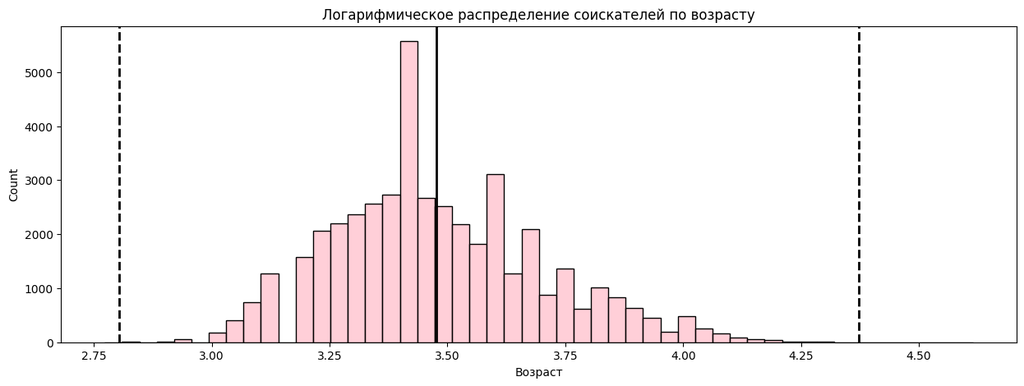

```python
fig, axes = plt.subplots(1, 1, figsize = (15, 5))
age_log = np.log(hh_df['Возраст'] + 1)

fhist = sns.histplot(age_log, bins = 50, ax = axes, color = 'pink')
fhist.axvline(age_log.mean(), color = "k", lw = 2)
fhist.axvline(age_log.mean() - 3 * age_log.std(), color = "k", ls = "--", lw = 2)
fhist.axvline(age_log.mean() + 4 * age_log.std(), color = "k", ls = "--", lw = 2)
fhist.set_title('Логарифмическое распределение соискателей по возрасту')

def z_score_mod(data, col, left = 3, right = 3):
    x = np.log(data[col] + 1)

    miu = x.mean()
    sigma = x.std()

    lower_bound = miu - left * sigma
    upper_bound = miu + right * sigma

    outliers = data[(x < lower_bound) | (x > upper_bound)]
    cleaned = data[(x > lower_bound) & (x < upper_bound)]

    # Число выбросов
    print(outliers.shape[0])
    return cleaned

cleaned = z_score_mod(hh_df, 'Возраст', 3, 4)
# Итоговое число записей
print(cleaned.shape[0])
hh_df = cleaned

# Сохраним очищенные данные
hh_df.to_csv('./hh_db_clean.csv')
```

### Выводы:

Распределение имеет асимметрию (правостороннюю).

```python
!pip install nbconvert
!jupyter nbconvert --to html Project-1-Final-HW.ipynb
```

```
[NbConvertApp] Converting notebook Project-1-Final-HW.ipynb to html
[NbConvertApp] WARNING | Alternative text is missing on 3 image(s).
[NbConvertApp] Writing 2355893 bytes to Project-1-Final-HW.html
```